# Compte rendu de la formation OPIDoR Tour, Lyon

M. Rolland

07/01/2020

# Présentation de la formation

> L’ [OPIDoR Tour](https://opidor.fr/) s’inscrit dans le cadre de la politique science ouverte de l’ANR notamment sur le volet données de la recherche.

> En effet, l’Agence demandera l’élaboration d’un plan de gestion des données pour tous les projets financés dans les 6 mois qui suivent le démarrage du projet et ce à partir de l’édition 2019.

> Un Plan de gestion des données (PGD) ou Data Management Plan (DMP) est un document évolutif décrivant la collecte, le traitement, la documentation, le stockage, l’archivage, la conservation et le partage des données tout au long de leur cycle de vie dans le cadre d’un projet de recherche.

> L’ANR a sollicité le [Comité pour la science ouverte (CoSO)](https://www.ouvrirlascience.fr/open-science/) pour bénéficier de [recommandations dans la mise en place de ce plan de gestion des données](https://www.ouvrirlascience.fr/plan-de-gestion-de-donnees-recommandations-a-lanr/).

Toutes les slides de la présentation [ici](https://tour.opidor.fr/wp-content/uploads/2020/01/OPIDoR_Tour_Lyon_20200107.pdf).

# Première partie - Le projet OPIDoR

OPIDoR = Optimiser le Partage et l’Interopérabilité des Données de la Recherche.

OPIDoR est une suite d’outils développés pour aider à la gestion des données de recherche et rendre la science plus ouverte, cap initié en France par la loi sur le numérique et formalisé par le [plan national pour la science ouverte](https://www.ouvrirlascience.fr/plan-national-pour-la-science-ouverte/) dont le leitmotiv semble être *“Aussi ouvert que possible, aussi fermé que nécessaire”*.

Un des éléments clé de ce plan est de systématiser la rédaction de Data Management Plans (DMP).

La suite OPIDoR aide en particulier à la rédaction de ces DMP. Ces outils sont développés et promus par l’ [Inist](https://www.inist.fr/), une équipe de recherche du CNRS développant des services numériques pour la recherche.

Les trois outils OPIDoR:

- **OPIDoR - DMP**: outil en ligne accompagnant la rédaction d’un DMP
- **OPIDoR - Cat**: catalogue contenant toutes les ressources françaises en lien avec les données de recherche
- **OPIDoR - PID**: service de l’Inist attribuant un DOI pour les données

Ces outils ont pour objectif de rendre les données de recherche plus FAIR*

[figure not shown]

Principes FAIR

*Facile a trouver, Accessible, Interopérable, Réutilisable

Le plan de gestion est un élément clé de cette “fairisation” (sic) des données.

- L’ANR va imposer l’inclusion d’un DMP pour tous les projets dès 2019
- Une version sommaire de DMP doit être soumise dans les 6 mois suivant le démarrage scientifique du projet, et elle doit etre mise à jour régulièrement
- ANR seront indulgents sur les DMP à 6 mois
- Le DMP est un livrable
- L’ANR propose un modele de DMP inclus dans l’outil DMP opidor. Il n’est pas obligatoire d’utiliser ce template.

Finalement l’Inist propose d’autres services complémentaires:

- DoRANum: plateforme e-learning sur la gestion des données (CoSo)
- Traitement des données (exposition de données)
- Conseil au choix d’un entrepôt
- Conseil à la préparation des (méta)données (entrepôt de données)

## L’outil DMP OPIDoR

Cet outil permet d’aider à la rédaction de DMP.

### Qu’est-ce qu’un data management plan (DMP)?

- Permet de planifier la gestion des données de la recherche
- Définit quelles données seront crées, et/ou collectées, comment elles vont être documentées, partagées et conservées pendant et apres le projet
- Permet d’anticiper les questions, et mettre en place et encourages les bonnes pratiques
- Doc dynamique (qui évolue)
- Prend en compte toutes les étapes du cycle de vie des données

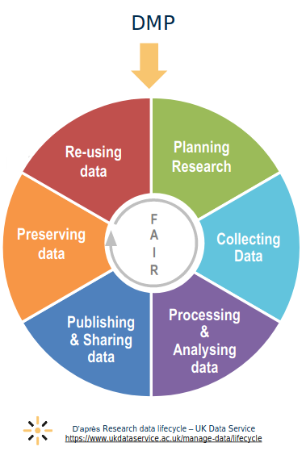

Le DMP contient:

- Données administratives et description du projet
- Rôles et responsabilités (mise en œuvre du DMP)
- Informations sur les données de recherche : types, formats, volumes, qualité…
- Standards et métadonnées
- Politique d’accès, de partage et de réutilisation des données
- Stockage, sauvegarde et conservation (archivage)
- Ressources allouées

### DMP - OPIDoR

DMP est un outil en ligne aidant à l’élaboration de son DMP.

Lien vers l’outil: https://dmp.opidor.fr

Notes générales sur l’outil

- open source
- contient de nombreux modèles de DMP (ANR, Europe, etc)
- hébergé à l’inist CNRS **en France**
- mis a disposition de la communauté scientifique et partenaires (ESR)
- outil collaboratif: les DMP créés dans l’outil opidor sont partgeables, commentaires, échanges, définir niveau de visibilité, demande d’assistance/accompagnement, finalement on peut télécharger le dmp
- il n’est pas obligé d’utiliser le modèle ANR pour soumettre un projet ANR (on peut utiliser un modèle local par ex ou inserm. L’Inra a un modèle Inra par ex)
- version anglaise bientot disponible
- le modèle par défaut est celui de la comission europenne projet H2020

Lien vers liste des templates de DMP: https://dmp.opidor.fr/public_templates

Lien vers template ANR: https://dmp.opidor.fr/template_export/1306665387.pdf

Notes sur l’utilisations de l’outil (plus de détails sur la présentation):

- si on veut juste faire un essai on peut cocher la case “projet test”
- produit de recherche = research output
- on peut ajouter des commentaires avec l’onglet a droite, ca envoie une alerte mail au respondable du DMP
- une fois rédigé on peut partager pour montrer a ses collègues, qui pourront commenter avec différents niveaux de droits
- intéressant de mettre les DMP visibles par tous pour promouvoir les bonnes pratiques
- **DMP OPIDOR N’A PAS VOCATION A ARCHIVER LES PLANS DE GESTION – ILS SONT SUPPRIMES APRES 5 ANS D’INACTIVITE** il faut donc toujours les télécharger
- on peut effectuer une copie pour une nouvelle version (pas de versionnage intégré)
- pour les institutions on peut créer un modèle local / template, ajouter des recommandations en contactant info-opidor@inist.fr
- il y a des exemples dans l’onglet resource de opidor (ils sont pas forcément aboutis, ce sont la plupart des premieres versions)
- on peut juste télécharger le template et le compléter en dehors de l’outil, opidor est juste une aide (note: téléch en local permet le versionning ce que ne permet pas encore DMP-opidor mais en cours de dév)

## L’outil Cat OPIDoR

cat = catalogue

Lien vers l’outil: https://cat.opidor.fr

- catalogue en ligne qui recense les services francais des données de la recherche
- wiki
- fait pour trouver toutes les réponses à nos questions
- il y a un mode de recherche par localisations (cf carte)

## L’outil PID OPIDoR

C’est un service de l’Inist permettant d’attribuer des DOI à ses données.

Lien vers le service: https://opidor.fr/identifier/

- permet d’attribuer un identifiant perenne aux données de la recherche aka DOI
- nos données peuvent ainsi être citées comme des publis
- attribués par DataCite (consortium qui gère l’attribution des doi ppalement pour les onnées de la recherche). inist membre francais de datacite
- inist peut fournir des préfixes DOI (Digital Object Identifier)
- c’est un triptique: nom + url + metadonnées
- url: envoie vers la page des données
- cycle d’attribution: contact inist => échange => contrat => création compte => creation de DOI
- coût: 180eur/ht par an pour un nombre illimité de DOI
- se renseigner si l’IAB cotise deja
- entrepôt de données recommandé : ZENODO
- plateforme d’archivage française = cines (!= entrepot de données)

# Deuxième partie - Atelier opidor

Cet atelier était un jeu pour aider à bien cerner le cycle de vie des données de recherches. Voici certains points notés en plus:

- il existe de nombreux entrepôts de données, pour choisir lequel est adapté à ses besoins regarder s’il y en a en dans sa thématique (données cohorte santé). y en a-t-il a l’inserm/iab?
- pour savoir quelles méta données remplir, se rensigner sur les standards de la thématique (pour nous par ex les cohortes en santé)
- pour le partage des données il est recommandé (dans la mesure du possible) des formats ouverts: CSV
- définition d’une donnée sensible: https://www.cnil.fr/fr/definition/donnee-sensible

# Conclusion

Cette présentation était principalement axée sur la présentation des outils OPIDoR et la rédaction de DMP, il n’était pas question de la mise en oeuvre: comment choisir son entrepôt de données, quelles meta-données, archivage sur le long terme, etc. Beaucoup de ces question sont domaine/thématique spécifiques, le plus pertinent est donc de commencer par se renseigner par ce qu’il se fait dans notre domaine.

Si on ne trouve pas de réponse à notre question sur l’outil CAT il ne faut pas hésiter à contacter l’Inist pour toute question, et il faut également identifier les acteurs locaux (souvent les bibliothèques universitaires) et événements locaux (me renseigner sur les data lunch à Grenoble).

L’outil DMP - OPIDoR semble effectivement simplifier la rédaction d’un DMP en nous accompagnant pas à pas dans la démarche. Au moins pour la première fois.

# Annexes

## Rappel des liens utiles

[Matériel présentation](https://tour.opidor.fr/wp-content/uploads/2020/01/OPIDoR_Tour_Lyon_20200107.pdf)

[Lien vers liste des templates de DMP](https://dmp.opidor.fr/public_templates)

[Lien vers template ANR](https://dmp.opidor.fr/template_export/1306665387.pdf)

[Outil OPIDoR - DMP](https://dmp.opidor.fr)

[Outil OPIDoR - CAT](https://cat.opidor.fr)

[Service OPIDoR - PID](https://opidor.fr/identifier/)